**Guideline for Business Trip**

By Prof. Seungchul Lee  
http://iai.postech.ac.kr/  
Industrial AI Lab. at POSTECH

# 1. 신청

- 출장을 가기전에
  - 출장 신청
  - 출장과 회의에 필요한 사전 지식들을 미리 숙지
- 지도교수님과 구두 확인 후 - 출장 전 미리 신청
- Povis - 인사/행정 - 출장 - 신청

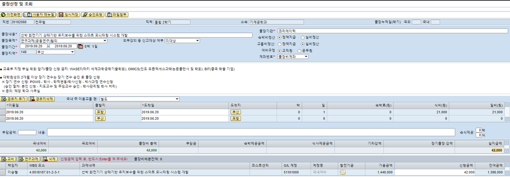

- 숙박비 - 정액지급, 교통비 - 실비정산
- 출장내용은 과제에 맞춰서 작성 (이혜령 선생님 확인 필)
  - 출장을 가는 과제가 실제 출장과 다를 수 있습니다.
  - 출장을 신청하는 과제 내용으로 작성해야 합니다.
- 연구과제 - (본인과제 체크해제) - 해당 과제 선택

# 2. 출장지

- 외부 기관과 회의를 하는 출장이면 복장에도 신경써야 합니다.
- 학생의 가장 좋은 모습은 적극적인 자세입니다.
  - 학생으로서 익숙하지 않고 힘들 수 있지만, 본인의 생각을 적극적으로 이야기하는 것이 중요합니다.
  - 본인의 신분이 학생이라는 것을 100% 활용하세요.
  - 학생은 실수를 해도 전혀 상관없습니다.
- 외부에서는 여러분이 우리 연구실과 포항공대의 얼굴입니다.
- KTX 영수증, 톨비 등의 교통비 증빙서류
- 학회 참석시 네임태그, 영수증등 증빙서류
- 연구실 홈페이지에 news 에 업로드할 필요가 있다고 판단되면 사진 촬영
- 1일마다 출장지 현지영수증

# 3. 복귀

- 사후정산
- 승인 받은 후 - 출력, 전표출력, 증빙서류 모아서 담당선생님께 전달
- 반드시 **회의록 작성 (구글캘린더)** 하고 교수님께 메일로 inform
  - follow-up action item 들을 명확히 명시

```python
%%javascript

$.getScript('https://kmahelona.github.io/ipython_notebook_goodies/ipython_notebook_toc.js')
```